# Divvy Bike Share Project Report

Author

Jingyu Huo

Published

December 9, 2025

Abstract

This report examines Divvy bike usage patterns in Chicago across seven distinct land-use types. Using trip-level records, station characteristics, and zoning data, I constructed station-level indicators—including mean hourly total trips, mean hourly net flow, usage frequency, bike-type preference, and extreme net flow per dock—to characterize weekday and weekend dynamics. The analysis reveals clear differences in bike demand, flow patterns, and operational stress across land-use contexts. Based on these findings, I provide actionable insights to support stakeholders and decision-makers in designing tailored bike-operation policies for each land-use type, with separate recommendations for weekdays and weekends.

## 1 Problem statement

How do Divvy bike usage patterns differ between weekdays and weekends across land-use types, in terms of trip volume, net flow, usage frequency, bike type preference, and net-flow extremes per dock?

## 2 Data sources

[Divvy Trip Dataset](https://divvy-tripdata.s3.amazonaws.com/index.html) - This dataset, provided by our client, contains all the divvy bike trips information from April 2020 to Octorber 2025. To keep the analysis computationally manageable while preserving seasonal representativeness, I used a three-month sample (August–October 2025)

[Divvy Bicycle Stations Map](https://data.cityofchicago.org/Transportation/Divvy-Bicycle-Stations-Map/bk89-9dk7) - This dataset contains location and dock number for each divvy bike station in chicago.

[Chicago Zoning District Boundaries](https://data.cityofchicago.org/d/7cve-jgbp) - This dataset contains the current land use type and boundary of each area in Chicago.

## 3 Data quality check / cleaning / preparation

### 3.1 Data Cleaning

#### 3.1.1 Dropping unecessary columns

The Chicago Zoning District dataset originally contains more than 20 variables. For the purpose of this analysis, only two columns were retained: the zone type column, which is used to classify stations by land-use category, and the area column, which contains the polygon boundaries of each zoning district. The dataset was then converted into a GeoDataFrame, with the boundary polygons specified as the geometry column. This step prepares the zoning data for spatial operations, including a spatial join with Divvy station locations in subsequent analysis.

```
ZONE_CLASS      object
geometry      geometry
dtype: object
```

The Divvy station dataset also contains many variables that are not required for this analysis. Only the station name column, which is used to join with the station-level summary statistics, and the dock count column, which is used to compute net flow per dock, were retained.

```
station_name    object
Docks            int64
dtype: object
```

|  | Docks |
| --- | --- |
| count | 1142.000000 |
| mean | 17.268827 |
| std | 13.290342 |
| min | 4.000000 |
| 25% | 12.000000 |
| 50% | 15.000000 |
| 75% | 16.000000 |
| max | 120.000000 |

#### 3.1.2 Handling Missing values

After checking all datasets, only the divvy trips data contains a large amount of missing values. The missing values are start and end station names and id, end location longitude and latitude. To calculate the bike usage pattern for a station, I need to calculate the bikes inflow and bikes outflow of a station from the trips data, so each trips record should have either a start station name or a end station name or both. Therefore, only records with both missing start station name and end station name are dropped.

```
ride_id                    0
rideable_type              0
started_at                 0
ended_at                   0
start_station_name    246975
start_station_id      246975
end_station_name      271323
end_station_id        271323
start_lat                  0
start_lng                  0
end_lat                 1898
end_lng                 1898
member_casual              0
dtype: int64
```

### 3.2 Data Preparation

#### 3.2.1 Modification of Chicago Zoning District Data

The zone type column in the Chicago Zoning District dataset originally contains zoning codes consisting of uppercase letter abbreviations followed by numbers indicating zoning intensity levels. To make these codes more interpretable for analysis, preprocessing was required to convert them into readable land-use categories.

The dataset contains 1,519 distinct zone type values, many of which differ only by numeric suffixes. To reduce unnecessary granularity, the numeric portions of the codes were removed and only the alphabetic abbreviations were retained. This step reduced the number of zone types to 14 distinct abbreviations.

These abbreviations were then mapped to their corresponding full land-use category names. However, even with this mapping, 14 categories remained too granular for stable analysis and clear interpretation. Therefore, the categories were further consolidated into seven broader land-use types: Downtown, Residential, Commercial, Industrial, Open Space, Planned Development and Transportation. This reclassification groups zoning categories that share similar functional roles and activity patterns.

For example, Downtown includes zoning subcategories such as Downtown Mixed-Use, Downtown Service, and Downtown Central Area, all of which represent high-intensity central urban environments and can be reasonably analyzed as a single category. Most detailed zoning types can be naturally mapped into one of the four primary land-use types: Downtown, Residential, Commercial, and Industrial. In contrast, Open Space, Planned Development Areas, and Transportation Districts do not fit cleanly into these four primary categories due to their distinct land use functions and planning purposes. To avoid forcing ambiguous classifications or excluding these observations from the analysis, each was retained as a separate land-use category.

#### 3.2.2 Modification of Divvy Trip Records

The Divvy trip records dataset required preprocessing before analysis. The original start and end time variables were stored as strings, so they were first converted into datetime objects. Using these datetime fields, I created new columns by extracting the date, day type (weekday or weekend), and hour from it. These derived variables enable subsequent grouping and aggregation operations at the daily and hourly levels.

The Divvy trip dataset consists of trip-level records, including start and end times as well as origin and destination stations. To examine station usage patterns, the raw trip-level data were aggregated to the station level.

Specifically, trips were grouped by station, hour, and day type (weekday or weekend), and key indicators were computed for each station–hour combination. These indicators include mean hourly total trips, which capture overall usage intensity, and mean hourly net flow, which reflects the balance between bike inflow and outflow at each station. This station-level aggregation enables consistent comparisons across locations while reducing noise from individual trips.

Each station was then assigned a land-use type based on its spatial location using Chicago zoning data. For visualization and analysis, station-level indicators were averaged within each land-use category. As a result, the plots reflect typical usage patterns associated with different land-use contexts

## 4 Exploratory Data Analysis

### 4.1 Mean hourly total trips and net flow on weekday/weekends across different land use types

To understand how bike usage patterns vary throughout the day across different land-use types, I first examine the mean hourly total trips and net flow for weekdays and weekends. By jointly analyzing trip volume and net flow, these plots capture not only when stations are most actively used, but also whether bikes are predominantly flowing into or out of stations at different times of the day.

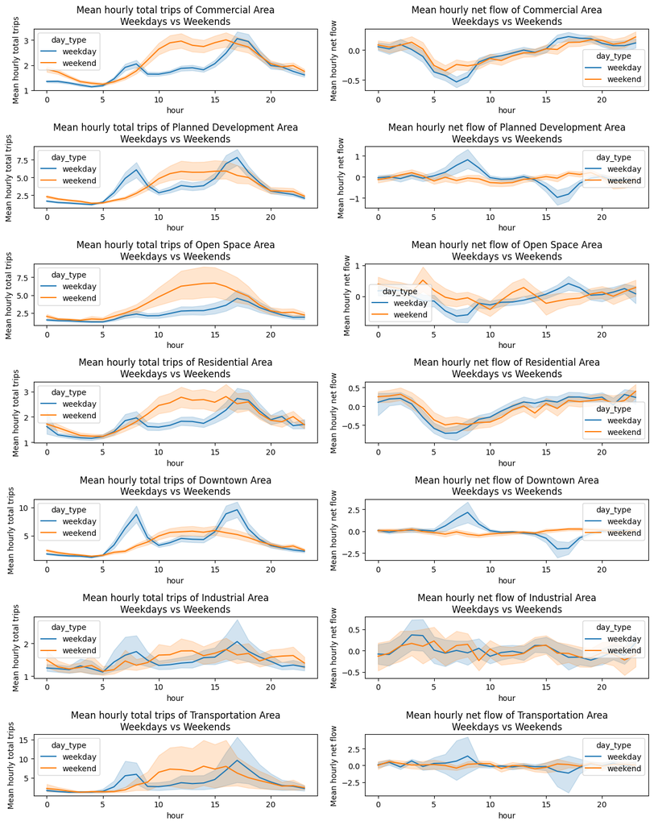

On weekdays, most land-use types exhibit two pronounced peaks in the morning and evening, reflecting typical commuting patterns. Downtown shows the sharpest peaks, reaching approximately 10 total trips per hour. Transportation areas also display high peak values, with total trips reaching similar magnitudes; however, these peaks are accompanied by substantial variability, fluctuating between fewer than 5 and up to nearly 15 trips per hour. In contrast, Open Space areas exhibit a single, less pronounced peak occurring later in the day.

On weekends, trip activity shifts toward the middle of the day across all land-use types, with peaks becoming broader and flatter. Open Space, Planned Development, and Downtown areas show the highest total trip volumes during midday hours. Transportation areas also maintain relatively high weekend trip volumes, with mean hourly trips around 7, but continue to exhibit large variability, ranging roughly from 5 to 15 trips per hour.

The net flow plots indicate whether bikes are predominantly departing from or arriving at stations. On weekdays, Residential, Commercial, and Open Space areas tend to export bikes in the morning and absorb bikes in the evening, while Downtown and Planned Development areas display the opposite pattern. On weekends, net flow across most land-use types is closer to zero, suggesting more balanced bike movements throughout the day. This shift is especially evident in Downtown and Planned Development areas, where the relatively structured inflow–outflow patterns observed on weekday mornings and evenings become much more stable and evenly distributed on weekends.

### 4.2 Pecentage increase of hourly total trips on weekends compare to weekdays across different land use types

From the mean hourly total trips and net flow plots, we observe clear differences between weekdays and weekends across land-use types. To further quantify these differences, we examine the hourly percentage change in total trips on weekends relative to weekdays, with the goal of identifying which land-use types experience the largest weekend increases in bike usage.

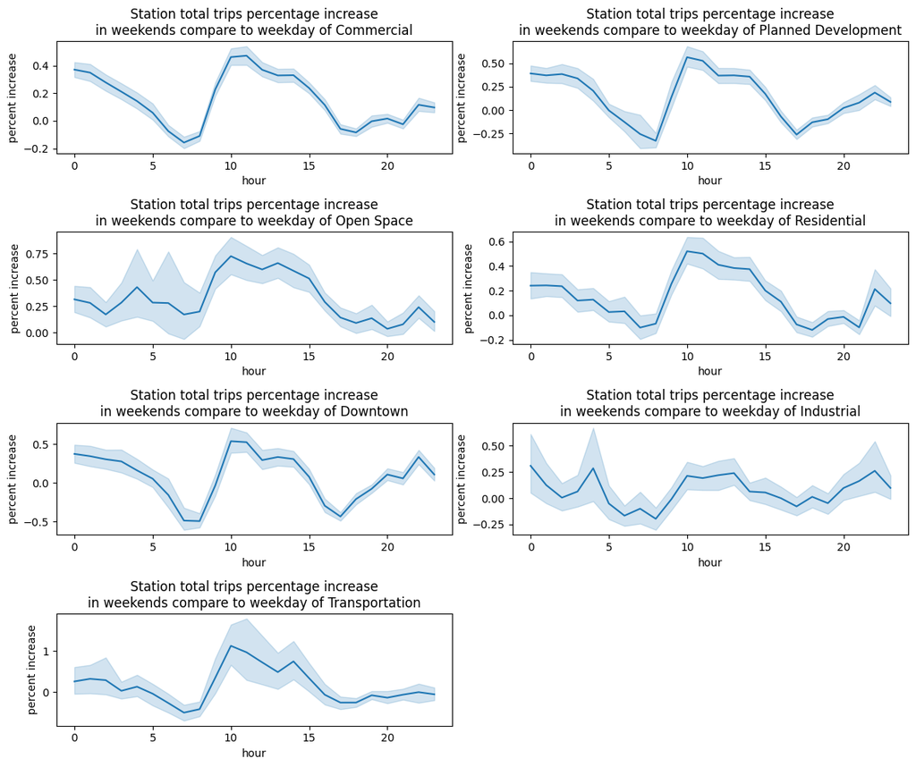

### 4.3 Station usage frequence on weekdays and weekends across different land use types

So far, the analysis has focused on intra-day patterns, examining how bike usage varies by hour within a day. We now shift to an inter-day perspective by analyzing station usage frequency across weekdays and weekends for different land-use types. Here, usage frequency is defined as the percentage of days over the three-month period in which a station records at least one trip.

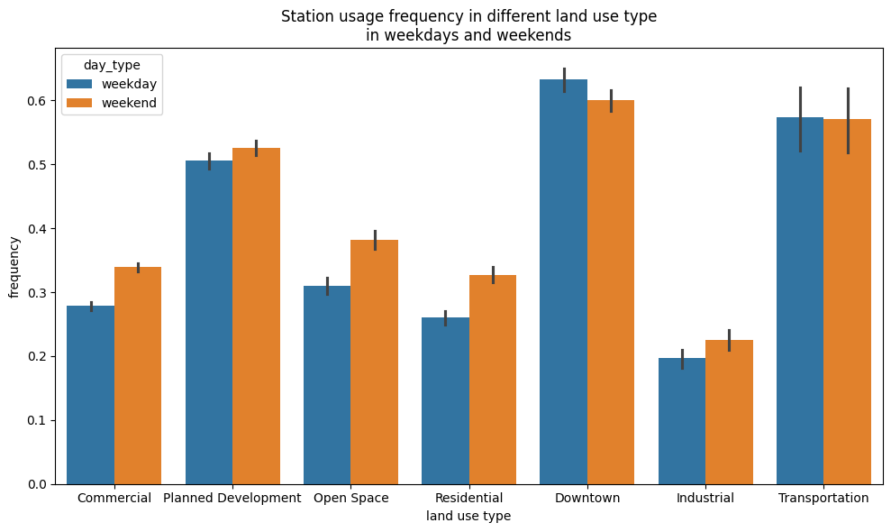

The results show that Downtown stations have the highest usage frequency, followed by Transportation and Planned Development areas. For most land-use types, station usage frequency is higher on weekends than on weekdays. Downtown is the main exception, where usage frequency is slightly higher on weekdays, reflecting its stronger association with regular weekday activity.

### 4.4 Proportion of electric bike trips versus classic bike trips across different land use types, separately for weekdays and weekends

In addition to how often and when bikes are used, we also examine what type of bikes are used, comparing the proportion of electric and classic bike trips across land-use types on weekdays and weekends.

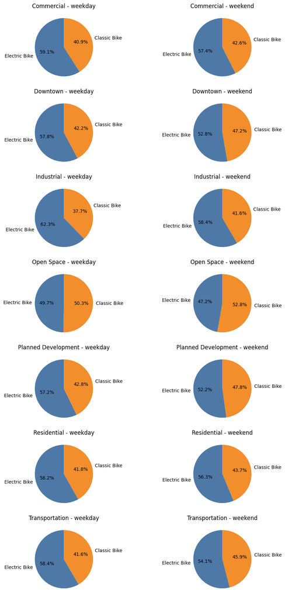

The results show that in most land-use types, electric bikes are used more frequently than classic bikes on both weekdays and weekends. The main exception is Open Space, where classic bikes account for a higher share of trips, likely reflecting more relaxed and recreational riding rather than time-sensitive travel. In addition, although classic bikes are generally used less than electric bikes, their usage increases on weekends across all land-use types, suggesting a shift toward more leisure-oriented travel on weekends.

### 4.5 Max & Min hourly net flow per dock

The previous analyses examined differences between weekdays and weekends across land-use types in terms of total trip volume, average net flow patterns within a day, usage frequency, and bike type preference. In this section, I revisit the net-flow indicator, but shift the focus from average behavior to extreme operational conditions.

Instead of analyzing the mean net flow across stations within each land-use type, I examine the maximum and minimum net flow per dock. Net flow per dock is defined as the mean hourly net flow of a station divided by the number of docks at that station. This metric captures the magnitude of bike inflow or outflow relative to station capacity, allowing us to assess operational stress.

A value close to 1 indicates extreme inflow: the number of bikes arriving within an hour is nearly equal to the station’s total dock capacity, meaning the station could become fully occupied within one hour even if it started empty. Conversely, a value close to –1 indicates extreme outflow: the number of bikes leaving is comparable to the station’s dock capacity, implying the station could be completely emptied within an hour even if all docks initially contained bikes. Therefore, net flow per dock provides a direct measure of station-level operational stress. Stations with absolute net flow per dock values greater than 0.5 are considered high-risk and may require rebalancing or other operational interventions.

To compute this metric, I merged the station-hour summary dataset—which includes mean hourly net flow and total trips—with Divvy station metadata containing dock counts, using station names as identifiers. The mean hourly net flow was then divided by the number of docks to obtain net flow per dock.

#### 4.5.1 Line plot of max and min hourly net flow per dock across land-use types on weekdays and weekends

The figure below presents the minimum and maximum net flow per dock observed within each hour of the day for weekdays and weekends, separated by land-use type. This visualization allows us to identify whether extreme net-flow stations occur within each land-use type, when stress events of these stations happen during the day, and whether they correspond to extreme inflow or outflow.

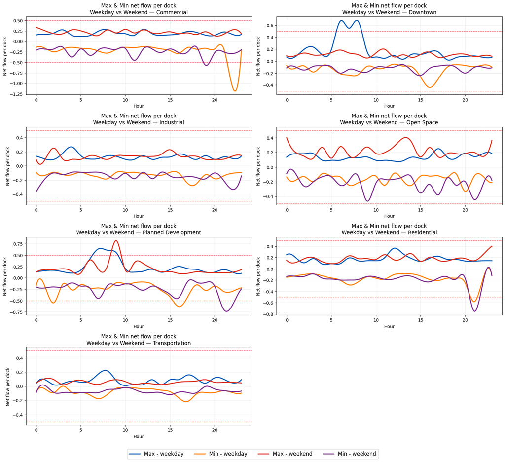

The plots reveal distinct extreme net-flow patterns across land-use types. Downtown areas exhibit extreme inflow during weekday morning hours, indicating strong bike accumulation at that time. Planned Development areas show sharp morning inflows on both weekdays and weekends, and additionally experience extreme outflows on weekday afternoons and weekend evenings, suggesting substantial fluctuations throughout the day. Commercial areas present the most severe late-night outflow on weekdays, with the minimum net flow per dock reaching approximately –1.25, indicating a strong risk of station depletion. Residential areas also experience pronounced late-night outflows on both weekdays and weekends, though the magnitude is slightly less extreme than in commercial zones.

#### 4.5.2 Count of times when a station has high hourly net flow per dock (greater than 0.5) on weekdays or weekends across different land use types

The previous line plot visualizes only the most extreme net flow per dock within each land-use type, based on the maximum and minimum values across stations. However, a single extreme value may represent either one station or multiple stations, and it does not capture situations where several stations experience substantial operational stress without reaching the absolute maximum or minimum.

To better understand the extent and concentration of extreme conditions, this analysis examines when extreme conditions occur and how many stations are affected simultaneously. The plots show, for selected land-use types, the number of stations exceeding the ±0.5 threshold at each hour of the day on weekdays and weekends. This allows us to identify time periods of concentrated operational pressure and assess whether extreme net flows are isolated incidents or system-wide events involving multiple stations.

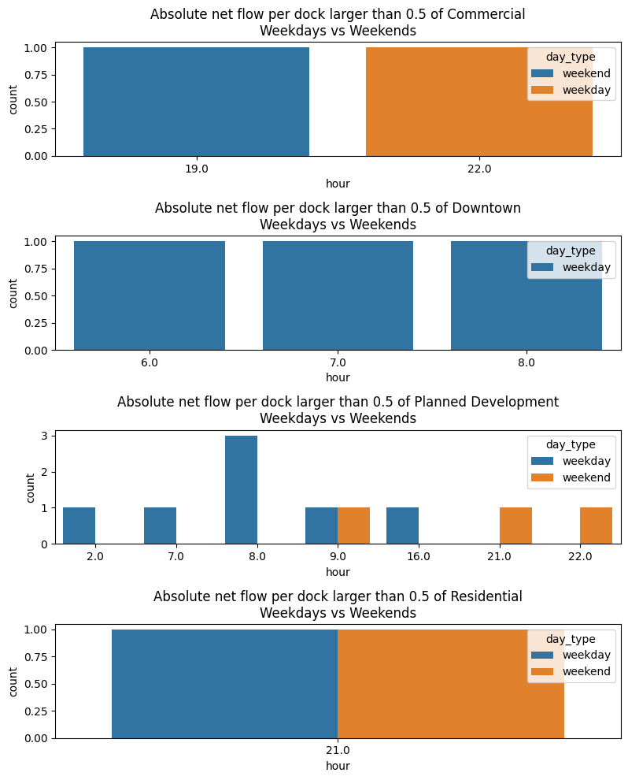

This figure includes four land-use types, as these are the categories that exhibited extreme net flow per dock values in the previous line plots.

For Commercial areas, the results are consistent with the line plots, showing isolated extreme net flow events during evening hours on both weekdays and weekends. Downtown and Residential areas also exhibit extreme events at the same hours identified previously. Importantly, for these three land-use types, the count at each extreme hour is one, indicating that only a single station experiences high operational stress at any given time.

In contrast, Planned Development areas show a more severe pattern. While the timing of extreme events generally aligns with the line plots, at 8 AM on weekdays the count reaches three. This indicates that, in addition to the most extreme station highlighted in the line plot, two additional stations also experience substantial net flow per dock values greater than 0.5 at the same hour. As a result, operational stress in Planned Development areas is most severe during weekday morning hours, particularly around 8 AM, when multiple stations simultaneously experience high inflow or outflow pressure.

## 6 Recommendations to stakeholder(s)

Based on the analysis results, bike allocation and rebalancing strategies should be tailored to both land-use type and time of day.

On weekdays, more bikes should be allocated to commuting-oriented areas, particularly Downtown and Planned Development areas, where strong and directional peak-hour demand is observed. Rebalancing operations should align with net flow patterns: bikes should be removed from stations during the morning peak to prevent overflow and replenished during the evening peak to avoid depletion.

On weekends, demand shifts from short, intense commuting periods to broader midday windows, roughly between 10:00 and 15:00. Although most land-use types exhibit near-zero mean net flow on weekends—indicating more balanced trips—Commercial, Residential, and Open Space areas still show noticeable variability and therefore require targeted rebalancing during specific hours.

Bike type composition should also be adjusted accordingly. The bike preference analysis indicates a stronger preference for electric bikes during commuting trips and relatively higher classic bike usage during leisure trips. As a result, stations across most land-use types should be supplied with a higher proportion of electric bikes on weekdays and relatively more classic bikes on weekends (compared to weekdays). Open Space areas are an exception, where classic bikes should be prioritized on both weekdays and weekends due to consistently leisure-oriented usage.

Finally, operational priority should be given to stations experiencing extreme net flow per dock, as these stations face higher risks of overflow or shortage regardless of overall trip volume. Planned Development areas, in particular, require special attention, as multiple stations experience extreme conditions during the same hours—most notably at 8 AM on weekdays, when three stations simultaneously exceed critical net flow thresholds.

However, since I only used three month of trip records, to obtain more robust and generalizable patterns, future analyses should incorporate additional years and months of trip data.